# Coding Assignment #1

Clayton Jones

2025-07-11

### Scenario 1: Exit Velocity by Pitch

*Create a visual that summarizes the exit velocity separated by pitch type and grouped by the 2023 and 2024 seasons. The plot will be like Figure 4.16 but will include a separate density plot for each year within a pitch type. Be sure that you have a proper title, x and y axis labels, and the full name for each pitch as opposed to the abbreviations (i.e., “Four-seam Fastball” as opposed to FF).*

[figure not shown]

Average Exit Velocity by Year

| Pitch | 2023 Average Exit Velocity (mph) | 2024 Average Exit Velocity (mph) | Difference |
| --- | --- | --- | --- |
| Sweeper | 84.42 | 96.19 | 11.77 |
| Knuckle Curve | 86.42 | 93.55 | 7.13 |
| Curveball | 92.64 | 88.11 | 4.53 |
| Cutter | 96.40 | 93.13 | 3.26 |
| 4-Seam Fastball | 97.25 | 94.19 | 3.06 |
| Changeup | 90.41 | 88.27 | 2.14 |
| Split-Finger | 93.47 | 92.23 | 1.24 |
| Sinker | 94.49 | 93.86 | 0.63 |
| Slider | 91.35 | 90.78 | 0.57 |
| Eephus | 97.20 | NA | NA |
| Slurve | 95.90 | NA | NA |

Pitch Counts

| Pitch | Number of Times Seen |
| --- | --- |
| 4-Seam Fastball | 1097 |
| Slider | 616 |
| Changeup | 551 |
| Sinker | 531 |
| Cutter | 366 |
| Curveball | 271 |
| Sweeper | 231 |
| Split-Finger | 212 |
|  | 85 |
| Knuckle Curve | 81 |
| Slurve | 16 |
| Other | 6 |
| Eephus | 2 |
| Forkball | 2 |
| Knuckleball | 1 |

### Scenario 2: Exit Velocity and Launch Angle

*Create a table that summarizes the average exit velocity, average launch angle, and frequency of occurrence for each unique event for both 2023 and 2024. Ensure that you have a proper title.*

| Event | Average Exit Velocity (mph) | Average Launch Angle | Frequency |
| --- | --- | --- | --- |
| double | 101.71739 | 17.3333333 | 69 |
| double_play | 106.65000 | 8.0000000 | 2 |
| field_error | 82.20000 | 0.3333333 | 3 |
| field_out | 90.36716 | 15.5021186 | 472 |
| fielders_choice | 74.50000 | -13.5000000 | 2 |
| force_out | 86.00667 | -7.6666667 | 15 |
| grounded_into_double_play | 89.16471 | -6.6470588 | 17 |
| home_run | 105.48696 | 28.5362319 | 69 |
| sac_fly | 95.06250 | 29.8750000 | 8 |
| single | 91.77485 | 4.7602339 | 171 |

**Question 1: Which event occurred most often?**  
As shown in Table 2, the most common event was a field_out, which is a ball put into play where Seager (the batter) gets out. This includes fly outs, pop outs, ground outs, lineouts.

**Question 2: Which event had the highest average exit velocity?**  
Surprisingly, according to Table 2, the highest average exit velocity was on double plays, not home runs. Statcast splits ‘double plays’ and ‘grounded into double plays’, which means that these events were likely line outs that were hit so hard that another runner was doubled off. This type of play can usually only occur when the ball is hit hard, which would make sense why it was the hardest. It only happened twice over two seasons. Among more common events, home runs had the highest average exit velocities, which would make the most sense.

*Create a visual like Figure 4.23 that summarizes the density of exit velocities for 2023 and 2024. Be sure that you have a proper title, x and y axis labels, and a legend.*

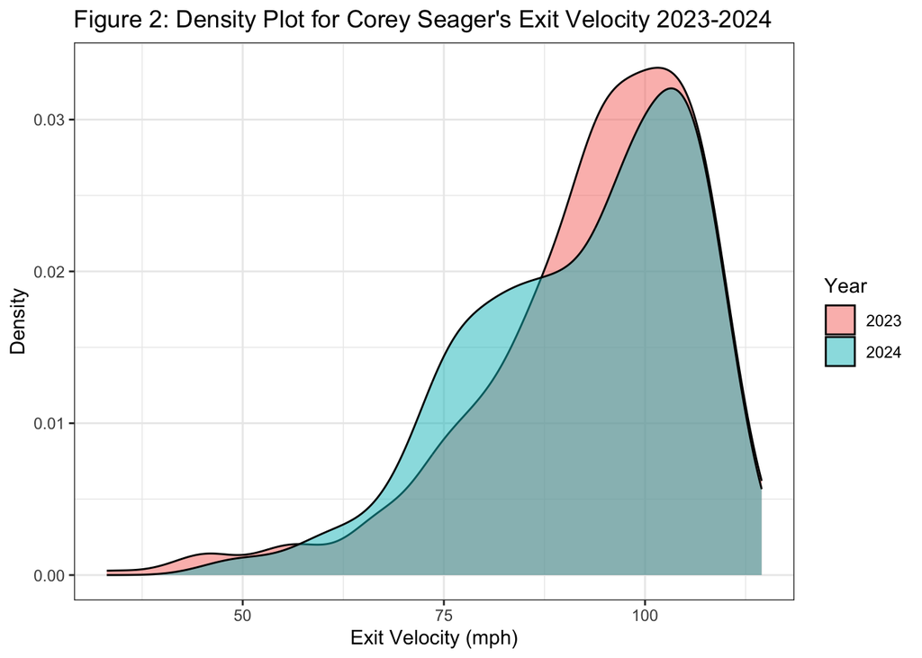

### Scenario 3: Swing Probabilities

*Create a visual like 4.28 that summarizes all hit-by-pitch for 2023 and 2024. Be sure that you have a proper title and x and y axis labels.*

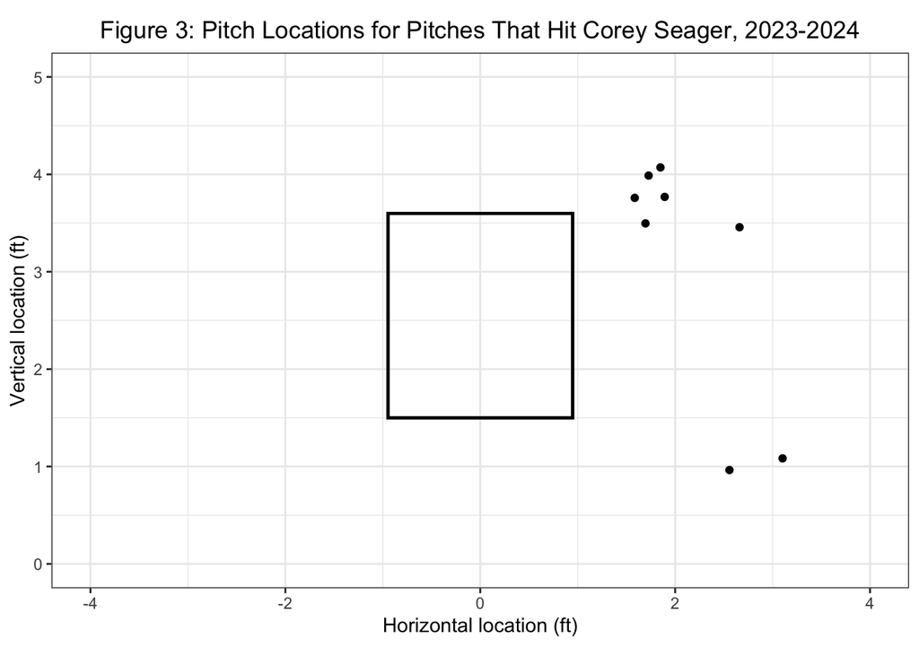

*Create two visuals (like the one on pg. 72) that produce a heat map summarizing swing probabilities for the 2023 and 2024 seasons separately. be sure that you have a proper title and x and y axis labels for each plot.*

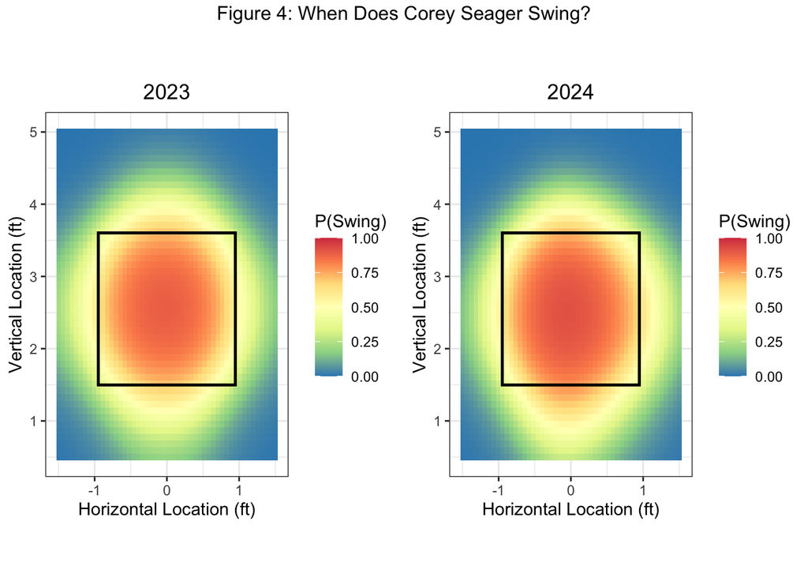

**Question 1: Discuss at least one key difference between the two years.**  
Looking at the two plots in Figure 4, if the pitch is in the strike zone, Seager is going to swing. Seager is known as an aggressive hitter, and these plots prove it. There is not a lot of difference between the two years. In 2024, Seager expanded below the zone and swung at pitchers below the strikezone a little bit more. Beyond that, there is hardly any difference between the two years.

*Create three visuals that summarize swing probabilities for Fastballs (FF, FT), Breaking Balls (CU, FC, SL), and Off-speed pitches (CH, FO, FS, SI, KN, KC, GY) combined for both 2023 and 2024. Be sure that you have a proper title and x and y axis labels for each plot. Include the total number of pitches seen for each group in the title.*

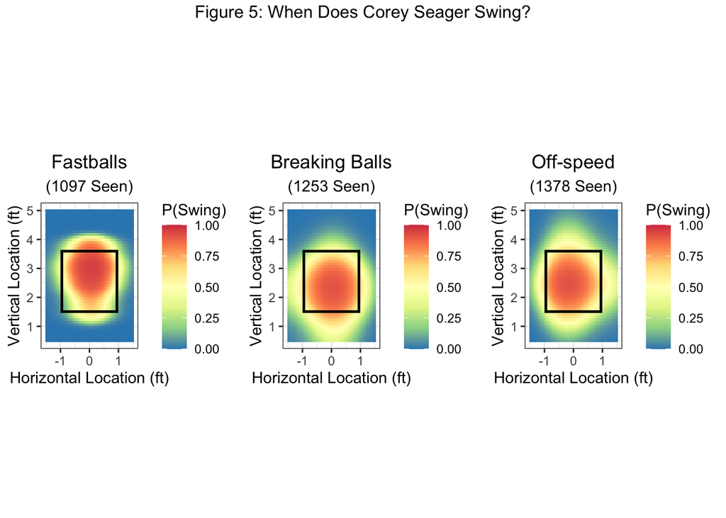